# Untitled

Eric Hirsch

12/13/2021

```r
library(kernlab)
library(readr)
library(caret)
library(tidyverse)
library(gridExtra)
library(janitor)
library(Matrix)
```

#### 1. Using the training.csv file, plot representations of the first 10 images to understand the data format. Go ahead and divide all pixels by 255 to produce values between 0 and 1. (This is equivalent to min-max scaling.) (5 points)

1. Read Data

```r
location = "work"

if (location=="work")
{
  mnist_raw <- read.csv("C:\\Users\\eric.hirsch\\Desktop\\RStudio\\605_Final\\Final\\MNIST.csv",header=TRUE)
} else if (loccation=="laptop")

{
  mnist_raw <- read.csv("D:\\RStudio\\CUNY_605\\Final\\MNIST.csv",header=TRUE)
} else

{
  mnist_raw <- read.csv("D:\\RStudio\\605_Final\\Final\\MNIST.csv",header=TRUE)
}
```

2. Scale Table

```r
mnist <- mnist_raw
colnames(mnist)[1]<-"Digit"
mnist[is.na(mnist)] <- 0

mnist_sample <- mnist[sample(nrow(mnist), 5000), ]
mnist_norm<-as.matrix(mnist[,-1]/255)
```

3. Plot the first 10 images

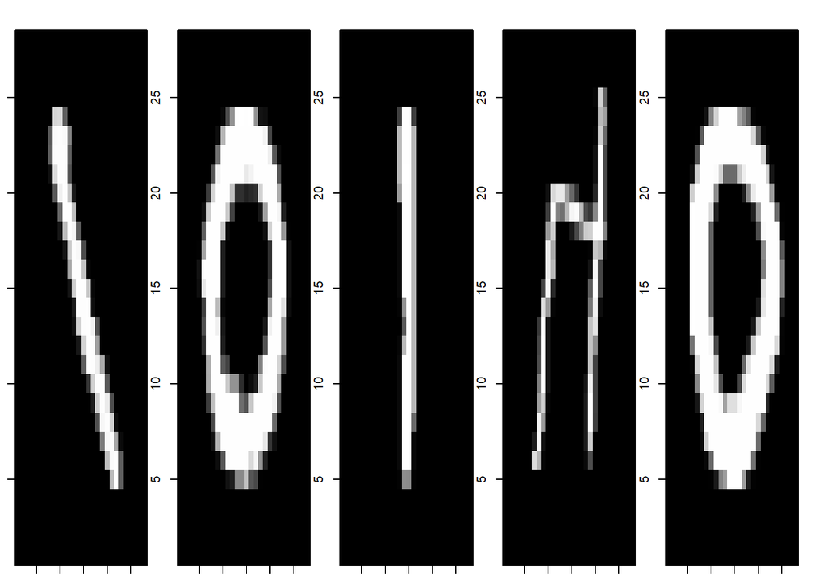

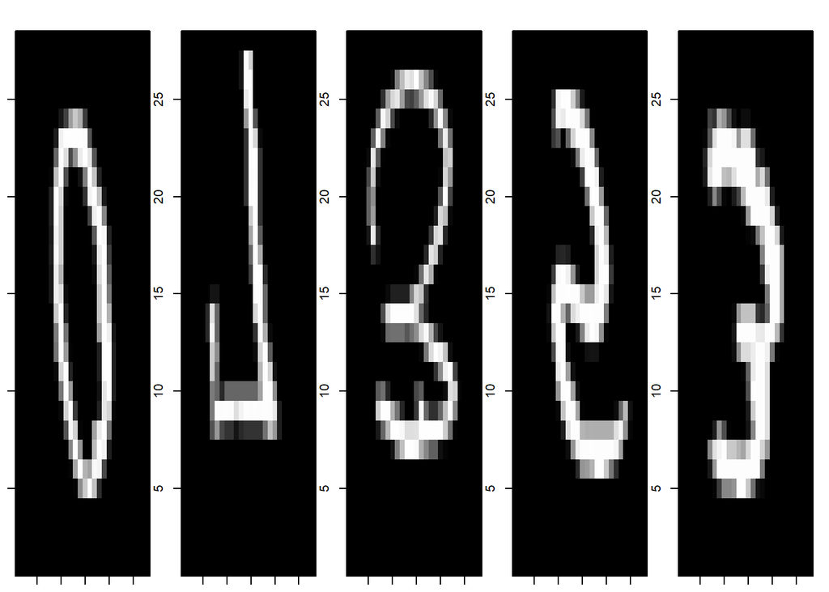

```r
par(mfcol=c(1,5), mar=c(1,1,2,1))

for (i in 1:10)
{
im2<-matrix((mnist[i,2:ncol(mnist)]), nrow=28, ncol=28)
im_numbers <- apply(im2, 2, as.numeric)
image(1:28, 1:28, im_numbers, col=gray((0:255)/255))
}
```

#### 2. What is the frequency distribution of the numbers in the dataset? (5 points)

```r
tabyl(mnist, Digit)
```

```
##  Digit    n    percent
##      0 4132 0.09838095
##      1 4684 0.11152381
##      2 4177 0.09945238
##      3 4351 0.10359524
##      4 4072 0.09695238
##      5 3795 0.09035714
##      6 4137 0.09850000
##      7 4401 0.10478571
##      8 4063 0.09673810
##      9 4188 0.09971429
```

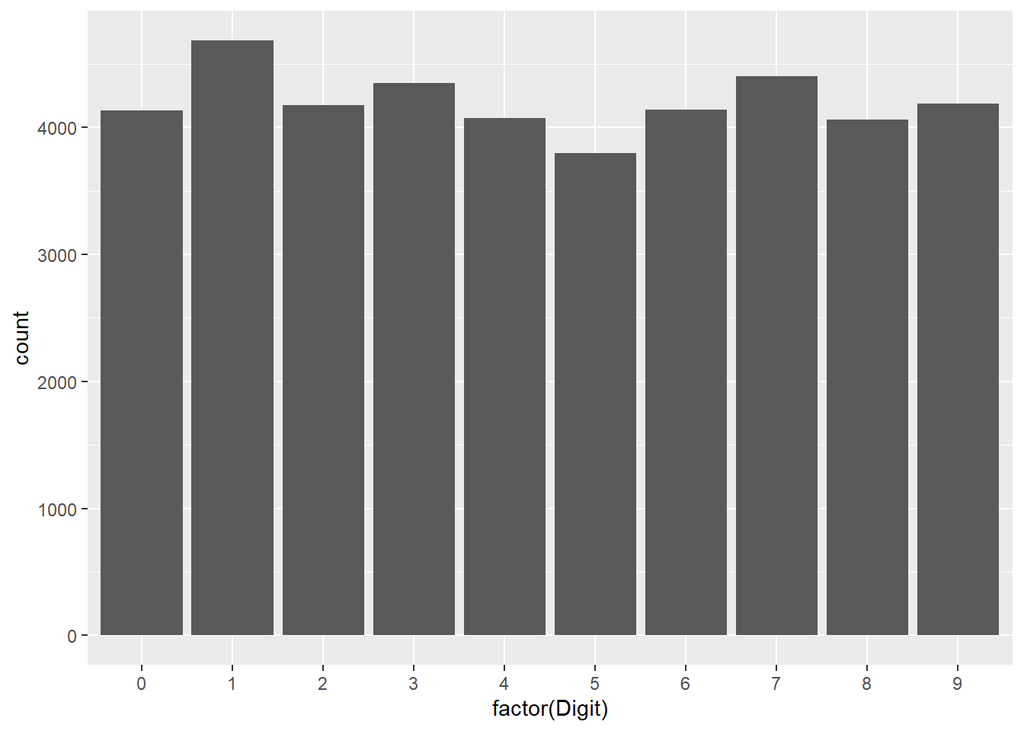

```r
# Don't map a variable to y
ggplot(mnist, aes(x=factor(Digit)))+
  geom_bar(stat="count")
```

The digits are fairly uniformly distributed, with 1s being the most represented (11.1%) and 5s the least (9.0%).

#### 3. For each number, provide the mean pixel intensity. What does this tell you? (5 points)

```r
dfMeans <- mnist
dfMeans$Mean <- apply(dfMeans[,2:785], 1, mean)

dfMeans2 <- dfMeans %>%
  group_by(Digit) %>%
  summarize(NumMean = mean(Mean))
dfMeans2
```

```
## # A tibble: 10 x 2
##    Digit NumMean
##    <int>   <dbl>
##  1     0    44.2
##  2     1    19.4
##  3     2    38.1
##  4     3    36.1
##  5     4    30.9
##  6     5    33.0
##  7     6    35.4
##  8     7    29.2
##  9     8    38.5
## 10     9    31.3
```

This tells us the relative space a number occupies within its matrix. We can see that the number 1, a simple line, occupies the least space. The seven, which is a line with a small attached segment, occupies somewhat more space. In contrast, the intensity of zero is more than twice that of 1, suggesting it occupies a lot of space. When we finish the analysis, it would be interesting to see whether there is more confusion between digits that occupy similar amounts of space.

#### 4. Reduce the data by using principal components that account for 95% of the variance. How many components did you generate? Use PCA to generate all possible components (100% of the variance). How many components are possible? Why? (5 points)

```r
#Perform PCA on the scaled matrix
mnist_norm_cov <- cov(mnist_norm)
pca <- prcomp(mnist_norm_cov)
```

```r
# Show the cumulative variance
variance_explained <- as.data.frame(pca$sdev^2/sum(pca$sdev^2))

variance_explained <- cbind(c(1:784),variance_explained,cumsum(variance_explained[,1]))

colnames(variance_explained) <- c("n","individual_var_explained","cumulative_var_explained")

head(variance_explained,20)
```

```
##     n individual_var_explained cumulative_var_explained
## 1   1              0.253270351                0.2532704
## 2   2              0.167822227                0.4210926
## 3   3              0.123230148                0.5443227
## 4   4              0.093947208                0.6382699
## 5   5              0.071681292                0.7099512
## 6   6              0.059224429                0.7691757
## 7   7              0.033648554                0.8028242
## 8   8              0.027394401                0.8302186
## 9   9              0.022898605                0.8531172
## 10 10              0.018043118                0.8711603
## 11 11              0.014170336                0.8853307
## 12 12              0.013316416                0.8986471
## 13 13              0.009437695                0.9080848
## 14 14              0.009378368                0.9174631
## 15 15              0.008139920                0.9256031
## 16 16              0.007201927                0.9328050
## 17 17              0.005678632                0.9384836
## 18 18              0.005341233                0.9438249
## 19 19              0.004571046                0.9483959
## 20 20              0.004332336                0.9527282
```

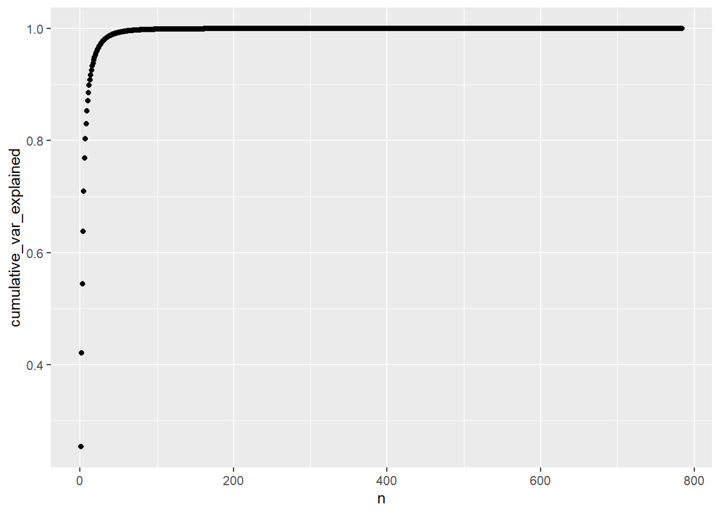

```r
ggplot(variance_explained, aes(n, cumulative_var_explained)) +
  geom_point()
```

I needed 20 components to account for 95% of the variance.

At 536 components, additional components no longer increase the variance explained. As for the total components actually possible, there would be 784 - unless there is collinearity, in which case there would be fewer.

#### 5. Plot the first 10 images generated by PCA. They will appear to be noise. Why? (5 points)

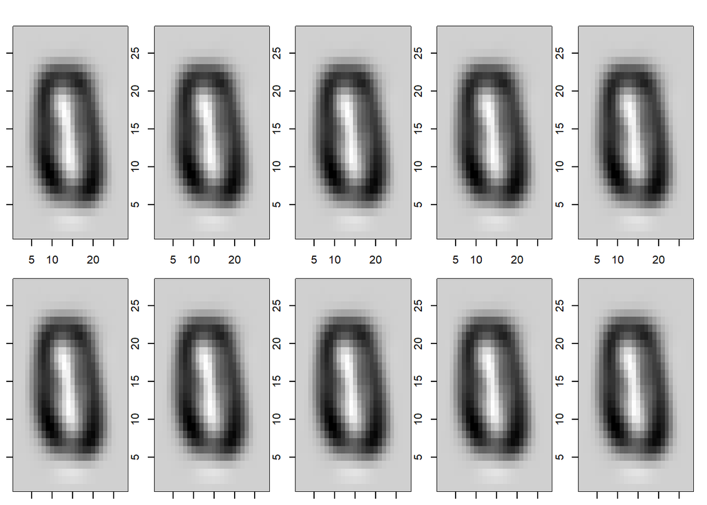

```r
# reconstruct matrix
restr <- pca$x[,1:20] %*% t(pca$rotation[,1:20])

# unscale and uncenter the data
if(pca$scale != FALSE){
  restr <- scale(restr, center = FALSE , scale=1/pca$scale)
}
if(all(pca$center != FALSE)){
  restr <- scale(restr, center = -1 * pca$center, scale=FALSE)
}

par(mfcol=c(2,5), mar=c(1,1,2,1))

for (i in 1:10)
{

rst <- matrix(data=rev(restr[i,]), nrow=28, ncol=28)
image(1:28, 1:28, rst, col=gray((0:255)/255))

}
```

PVC does not ccount for digit groupings, so these images are a mix of all digits - they capture the sort of average uber digit, which mystically enough looks like a zero.

the variance (100%). Plot the first 10 images. What do you see? (5 points)

Now if we filter just for the digit 8:

```r
mnist8 <- mnist %>%
  filter(Digit==8)

mnist_norm8<-as.matrix(mnist8[,-1]/255)

mnist_norm_cov8 <- cov(mnist_norm8)
pca8 <- prcomp(mnist_norm_cov8)
```

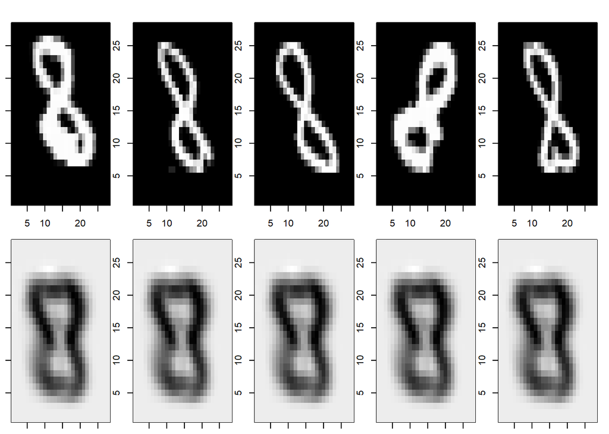

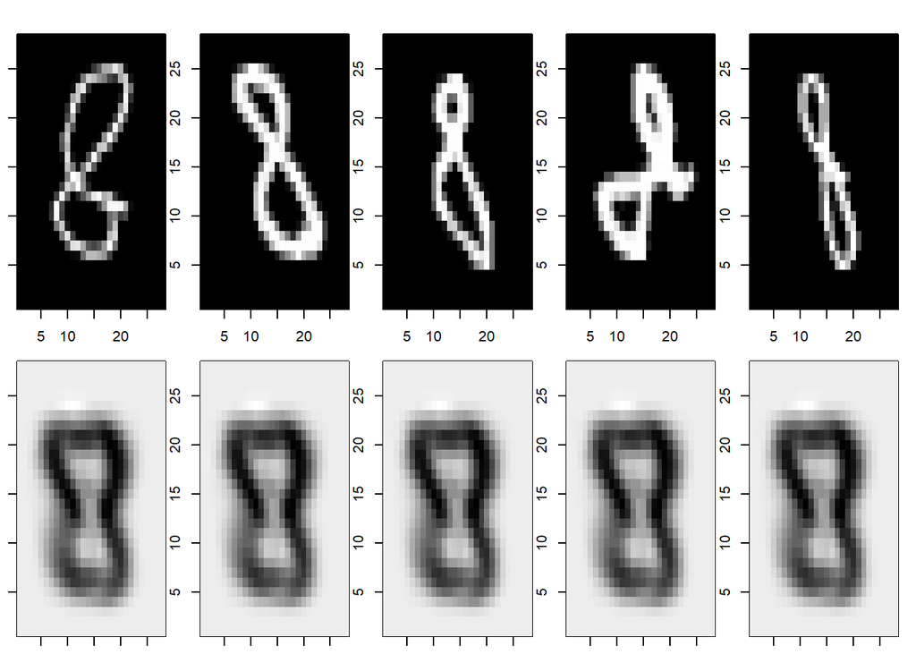

```r
restr <- pca8$x[,1:784] %*% t(pca8$rotation[,1:784])

par(mfcol=c(2,5), mar=c(1,1,2,1))

for (i in 1:10)
{

im2<-matrix((mnist8[i,2:ncol(mnist8)]), nrow=28, ncol=28)
im_numbers <- apply(im2, 2, as.numeric)
image(1:28, 1:28, im_numbers, col=gray((0:255)/255))

rst <- matrix(data=rev(restr[i,]), nrow=28, ncol=28)
image(1:28, 1:28, rst, col=gray((0:255)/255))

}
```

#### 7. Build a multinomial model on the entirety of the training set. Then provide its classification accuracy (percent correctly identified) as well as a matrix of observed versus forecast values (confusion matrix). This matrix will be a 10 x 10, and correct classifications will be on the diagonal. (10 points)

This is the model:

```r
# Load the nnet package
require(nnet)
mnist_raw[is.na(mnist_raw)] <- 0
mnist_scaled1 <- as.data.frame(mnist_raw/255)
mnist_scaled1[,1] <- mnist_raw[,1]
colnames(mnist_scaled1)[1]<-"Digit"
```

```r
# Train the model
#m_1 <- multinom(Digit ~ ., data=mnist_scaled1, MaxNWts =1000000, maxit=1000)

m_1 <- multinom(Digit ~ ., data=mnist_scaled1, MaxNWts =1000000, maxit=10)
#Make predictions
training_pred <- predict(m_1, mnist_scaled1)
```

This is the confusion matrix for the model

```r
cm <- table(training_pred, mnist_scaled1$Digit)
cm
```

```
##
## training_pred    0    1    2    3    4    5    6    7    8    9
##             0 2817    0   24   38   13   55   51   10   43   27
##             1    1 4150   12    3    4   33    7    8   50   10
##             2   29   44 3511  103   22   27   15   58   49   18
##             3   35   94   66 3793   18  320    4   36  162   96
##             4   22    3  132   15 3754  132   68   59   41  226
##             5  972    1   12   94    1 2397   43    6   64    5
##             6   75   15   88   51   28  105 3896    3   38    0
##             7   84  124  182  113   28  107   11 4122  135  363
##             8   80  249  118   92   44  503   41   13 3409   30
##             9   17    4   32   49  160  116    1   86   72 3413
```

This is the accuracy for the model

```r
sum(diag(cm))/sum(cm)
```

```
## [1] 0.8395714
```